# Dementia Classification With and Without MRI-Derived Features

A leakage-safe OASIS-2 machine-learning portfolio project

Author

Portfolio project

**Artifact provenance:** canonical release `ec26697ccaf9b788`; analysis manifest `2e979ea59364c04ccd88e94040098bfcca2e6a48d554dee2fcb9607a3416ea4c`.

# 1 Executive summary

This project asks whether three structured MRI-derived measurements improve subject-level dementia classification beyond a compact clinical feature set. Five algorithms were compared under both feature settings using the same persistent, entirely real held-out test set.

Balanced accuracy is the primary metric. With real-only training, the strongest held-out values were **0.866** for clinical features and **0.839** for clinical-imaging features. With 1:1 synthetic augmentation, the strongest values were **0.902** and **0.933**, respectively. Every augmented point estimate improved or tied its paired real-only estimate. Nine of ten paired 95% bootstrap intervals included zero; only decision-tree/clinical-imaging excluded zero (+0.188, interval +0.045 to +0.348). These exploratory, unadjusted comparisons use the same 30 previously inspected test subjects and do not establish that augmentation will generalize.

MMSE produced the largest held-out permutation-importance decrease in every model/feature-set experiment. This describes model reliance in this sample; it does not establish causality, clinical importance, or diagnostic validity.

# 2 Data and study question

The [OASIS-2 longitudinal release](https://pmc.ncbi.nlm.nih.gov/articles/PMC2895005/) contains MRI and associated clinical data from older adults with and without dementia. The source paper reports 150 subjects and 373 imaging sessions. This project uses the supplied longitudinal table and retains the complete row at each subject’s highest visit number.

|  | Stage | Rows | Unique subjects |
| --- | --- | --- | --- |
| 0 | Raw longitudinal | 373 | 150 |
| 1 | Final-visit subject table | 150 | 150 |
| 2 | Real training partition | 120 | 120 |
| 3 | Real held-out partition | 30 | 30 |

The binary target maps `Nondemented` to 0 and both `Demented` and `Converted` to 1. Because predictors such as MMSE are measured contemporaneously with the selected visit and outcome, this is a **classification** analysis—not early detection, conversion forecasting, or prognosis.

## 2.1 Feature settings

|  | Feature setting | Numeric predictors | Categorical predictors |
| --- | --- | --- | --- |
| 0 | clinical | age, education_years, ses, mmse | sex |
| 1 | clinical_imaging | age, education_years, ses, mmse, etiv, nwbv, asf | sex |

Raw numeric `education_years` is retained. Identifiers, original diagnostic group, visit metadata, handedness, and CDR are excluded from predictors. CDR is treated as outcome-defining leakage.

# 3 Leakage-safe experimental design

```
flowchart LR
  A["373 longitudinal visits"] --> B["Deterministic cleaning"]
  B --> C["150 final-visit subjects"]
  C --> D["120 real training subjects"]
  C --> E["30 real held-out subjects"]
  D --> F["Fold-local imputation, encoding, and scaling"]
  D --> S["Feature-set-specific, fold-local synthesis"]
  S --> F
  F --> G["Repeated stratified CV and tuning"]
  G --> H["Fixed final pipelines"]
  H --> I["One formal prediction release"]
  E --> I
  I --> J["Bootstrap uncertainty and explanation"]
```

Subjects are split after deterministic cleaning and final-visit selection but before learned preprocessing. Imputation, encoding, and scaling remain inside scikit-learn pipelines and are learned separately within each training fold. No subject appears in both partitions.

The 120-subject training partition contains 58 class-0 and 62 class-1 subjects. The held-out partition contains 14 class-0 and 16 class-1 subjects. The same held-out subjects are used for every final experiment.

# 4 Baselines and training-only model development

The baseline used repeated stratified five-fold cross-validation with 10 repeats. Hyperparameter selection used 15 shared training-only folds (five folds repeated three times), with balanced accuracy as the selection metric. Preprocessing was fitted inside each fold.

|  | Algorithm | Feature setting | Balanced accuracy mean | Balanced accuracy SD | ROC AUC mean | ROC AUC SD |
| --- | --- | --- | --- | --- | --- | --- |
| 0 | dummy | clinical | 0.500 | 0.000 | 0.500 | 0.000 |
| 1 | logistic_regression | clinical | 0.803 | 0.079 | 0.877 | 0.065 |
| 2 | dummy | clinical_imaging | 0.500 | 0.000 | 0.500 | 0.000 |
| 3 | logistic_regression | clinical_imaging | 0.807 | 0.090 | 0.882 | 0.066 |

|  | Algorithm | Feature setting | Balanced accuracy mean | Balanced accuracy SD | ROC AUC mean | ROC AUC SD |
| --- | --- | --- | --- | --- | --- | --- |
| 0 | logistic_regression | clinical | 0.800 | 0.071 | 0.881 | 0.064 |
| 1 | svm | clinical | 0.805 | 0.080 | 0.877 | 0.062 |
| 2 | decision_tree | clinical | 0.725 | 0.078 | 0.816 | 0.055 |
| 3 | random_forest | clinical | 0.751 | 0.058 | 0.847 | 0.057 |
| 4 | xgboost | clinical | 0.767 | 0.068 | 0.855 | 0.061 |
| 5 | logistic_regression | clinical_imaging | 0.811 | 0.076 | 0.876 | 0.062 |
| 6 | svm | clinical_imaging | 0.783 | 0.086 | 0.871 | 0.056 |
| 7 | decision_tree | clinical_imaging | 0.762 | 0.057 | 0.815 | 0.067 |
| 8 | random_forest | clinical_imaging | 0.774 | 0.048 | 0.853 | 0.056 |
| 9 | xgboost | clinical_imaging | 0.787 | 0.063 | 0.862 | 0.061 |

# 5 Fixed held-out evaluation

The selected pipelines were fitted on all 120 real training subjects and then evaluated on the persistent 30-subject real test partition. No threshold was tuned; standard estimator predictions were used.

|  | Algorithm | Feature setting | Balanced accuracy | ROC AUC | Sensitivity | Specificity | Precision | F1 |
| --- | --- | --- | --- | --- | --- | --- | --- | --- |
| 0 | decision_tree | clinical | 0.866 | 0.904 | 0.875 | 0.857 | 0.875 | 0.875 |
| 1 | decision_tree | clinical_imaging | 0.746 | 0.734 | 0.562 | 0.929 | 0.900 | 0.692 |
| 2 | logistic_regression | clinical | 0.808 | 0.951 | 0.688 | 0.929 | 0.917 | 0.786 |
| 3 | logistic_regression | clinical_imaging | 0.808 | 0.960 | 0.688 | 0.929 | 0.917 | 0.786 |
| 4 | random_forest | clinical | 0.844 | 0.960 | 0.688 | 1.000 | 1.000 | 0.815 |
| 5 | random_forest | clinical_imaging | 0.777 | 0.938 | 0.625 | 0.929 | 0.909 | 0.741 |
| 6 | svm | clinical | 0.804 | 0.951 | 0.750 | 0.857 | 0.857 | 0.800 |
| 7 | svm | clinical_imaging | 0.777 | 0.946 | 0.625 | 0.929 | 0.909 | 0.741 |
| 8 | xgboost | clinical | 0.866 | 0.933 | 0.875 | 0.857 | 0.875 | 0.875 |
| 9 | xgboost | clinical_imaging | 0.839 | 0.933 | 0.750 | 0.929 | 0.923 | 0.828 |

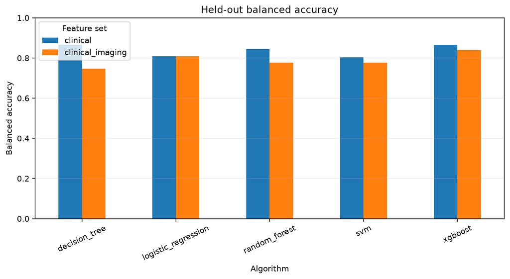

Balanced accuracy for the ten fixed held-out experiments.

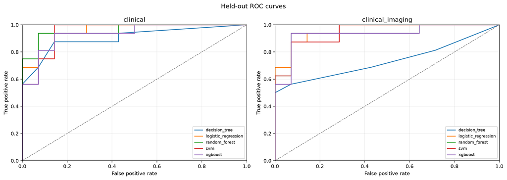

Held-out ROC curves.

These estimates describe only this small held-out sample. They are not a basis for clinical or deployment claims.

# 6 Synthetic augmentation experiment

Phase 8 added one synthetic subject for every real training subject. Separate Gaussian-copula generators were used for the two feature settings: the clinical generator never received MRI-derived variables. During tuning, each generator was fitted only on the real subjects in a fold’s training subset; the fold’s validation subjects remained entirely real. Target-conditioned sampling preserved the observed class counts rather than artificially balancing them.

For final training, each generator was fitted on the 120 real training subjects and produced 120 unique synthetic subjects: 58 class 0 and 62 class 1. No complete synthetic record exactly matched a real training record. The held-out test set was never used for synthesis.

|  | Feature setting | Real rows | Synthetic rows | Exact real matches | Diagnostic score | Quality score |
| --- | --- | --- | --- | --- | --- | --- |
| 0 | clinical | 120 | 120 | 0 | 1.0 | 0.813 |
| 1 | clinical_imaging | 120 | 120 | 0 | 1.0 | 0.776 |

The SDV diagnostic checks structure and value validity. The quality score summarizes marginal and pairwise statistical similarity; it is not a privacy guarantee and does not guarantee predictive utility.

|  | Algorithm | Feature setting | Balanced accuracy | ROC AUC | Sensitivity | Specificity | Precision | F1 |
| --- | --- | --- | --- | --- | --- | --- | --- | --- |
| 0 | decision_tree | clinical | 0.902 | 0.906 | 0.875 | 0.929 | 0.933 | 0.903 |
| 1 | decision_tree | clinical_imaging | 0.933 | 0.922 | 0.938 | 0.929 | 0.938 | 0.938 |
| 2 | logistic_regression | clinical | 0.839 | 0.955 | 0.750 | 0.929 | 0.923 | 0.828 |
| 3 | logistic_regression | clinical_imaging | 0.812 | 0.915 | 0.625 | 1.000 | 1.000 | 0.769 |
| 4 | random_forest | clinical | 0.902 | 0.960 | 0.875 | 0.929 | 0.933 | 0.903 |
| 5 | random_forest | clinical_imaging | 0.777 | 0.915 | 0.625 | 0.929 | 0.909 | 0.741 |
| 6 | svm | clinical | 0.808 | 0.853 | 0.688 | 0.929 | 0.917 | 0.786 |
| 7 | svm | clinical_imaging | 0.844 | 0.924 | 0.688 | 1.000 | 1.000 | 0.815 |
| 8 | xgboost | clinical | 0.871 | 0.946 | 0.812 | 0.929 | 0.929 | 0.867 |
| 9 | xgboost | clinical_imaging | 0.902 | 0.902 | 0.875 | 0.929 | 0.933 | 0.903 |

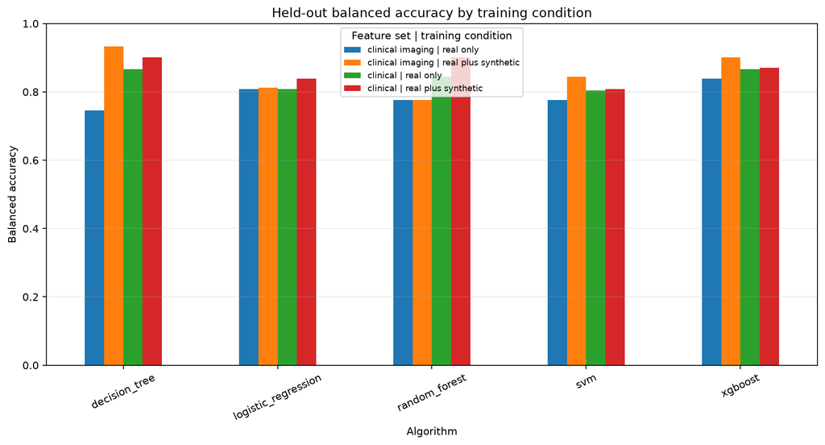

Balanced accuracy across both training conditions.

|  | Algorithm | Feature setting | Augmented - real-only |
| --- | --- | --- | --- |
| 0 | decision_tree | clinical | 0.036 |
| 1 | decision_tree | clinical_imaging | 0.188 |
| 2 | logistic_regression | clinical | 0.031 |
| 3 | logistic_regression | clinical_imaging | 0.004 |
| 4 | random_forest | clinical | 0.058 |
| 5 | random_forest | clinical_imaging | 0.000 |
| 6 | svm | clinical | 0.004 |
| 7 | svm | clinical_imaging | 0.067 |
| 8 | xgboost | clinical | 0.004 |
| 9 | xgboost | clinical_imaging | 0.062 |

The largest point-estimate difference was +0.188 for the clinical-imaging decision tree.

|  | Algorithm | Feature setting | Estimate | 95% lower | 95% upper |
| --- | --- | --- | --- | --- | --- |
| 0 | decision_tree | clinical | 0.902 | 0.795 | 1.000 |
| 1 | decision_tree | clinical_imaging | 0.933 | 0.830 | 1.000 |
| 2 | logistic_regression | clinical | 0.839 | 0.710 | 0.964 |
| 3 | logistic_regression | clinical_imaging | 0.812 | 0.688 | 0.938 |
| 4 | random_forest | clinical | 0.902 | 0.795 | 1.000 |
| 5 | random_forest | clinical_imaging | 0.777 | 0.643 | 0.906 |
| 6 | svm | clinical | 0.808 | 0.674 | 0.938 |
| 7 | svm | clinical_imaging | 0.844 | 0.719 | 0.938 |
| 8 | xgboost | clinical | 0.871 | 0.741 | 0.969 |
| 9 | xgboost | clinical_imaging | 0.902 | 0.795 | 1.000 |

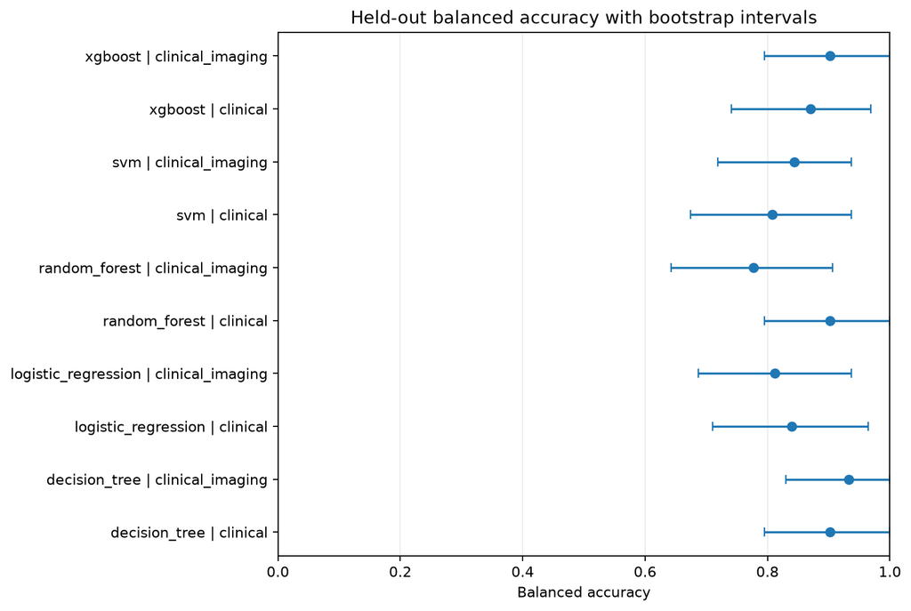

Augmented balanced accuracy with percentile bootstrap intervals.

|  | Algorithm | Feature setting | Augmented - real-only | 95% lower | 95% upper | Includes zero |
| --- | --- | --- | --- | --- | --- | --- |
| 0 | decision_tree | clinical | 0.036 | -0.103 | 0.179 | True |
| 1 | decision_tree | clinical_imaging | 0.188 | 0.045 | 0.348 | False |
| 2 | logistic_regression | clinical | 0.031 | 0.000 | 0.094 | True |
| 3 | logistic_regression | clinical_imaging | 0.004 | -0.094 | 0.107 | True |
| 4 | random_forest | clinical | 0.058 | -0.049 | 0.183 | True |
| 5 | random_forest | clinical_imaging | 0.000 | 0.000 | 0.000 | True |
| 6 | svm | clinical | 0.004 | -0.094 | 0.107 | True |
| 7 | svm | clinical_imaging | 0.067 | 0.000 | 0.170 | True |
| 8 | xgboost | clinical | 0.004 | -0.094 | 0.107 | True |
| 9 | xgboost | clinical_imaging | 0.062 | 0.000 | 0.156 | True |

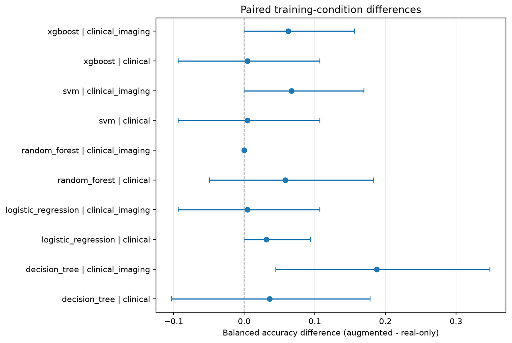

Paired augmented-minus-real-only balanced-accuracy differences.

Identical class-stratified subject draws were used across training conditions. Nine of ten intervals included zero. Only the decision-tree/clinical-imaging interval excluded zero, at +0.188 (95% percentile interval +0.045 to +0.348). These are unadjusted intervals conditional on fixed models, one synthetic run, and the same previously inspected 30-subject test set. They do not capture training, tuning, synthesis, or external-population variability and do not establish a general augmentation benefit.

# 7 Robustness and the MRI comparison

For the real-only feature-set comparison, stratified subject-level bootstrap resampling preserved the 14/16 class counts in each of 5,000 replicates. Identical subject draws were used across models, allowing paired clinical-imaging-minus-clinical comparisons.

|  | Algorithm | Feature setting | Estimate | 95% lower | 95% upper |
| --- | --- | --- | --- | --- | --- |
| 0 | decision_tree | clinical | 0.866 | 0.732 | 0.969 |
| 1 | decision_tree | clinical_imaging | 0.746 | 0.612 | 0.875 |
| 2 | logistic_regression | clinical | 0.808 | 0.674 | 0.938 |
| 3 | logistic_regression | clinical_imaging | 0.808 | 0.674 | 0.938 |
| 4 | random_forest | clinical | 0.844 | 0.719 | 0.938 |
| 5 | random_forest | clinical_imaging | 0.777 | 0.643 | 0.906 |
| 6 | svm | clinical | 0.804 | 0.656 | 0.938 |
| 7 | svm | clinical_imaging | 0.777 | 0.643 | 0.906 |
| 8 | xgboost | clinical | 0.866 | 0.732 | 0.969 |
| 9 | xgboost | clinical_imaging | 0.839 | 0.710 | 0.964 |

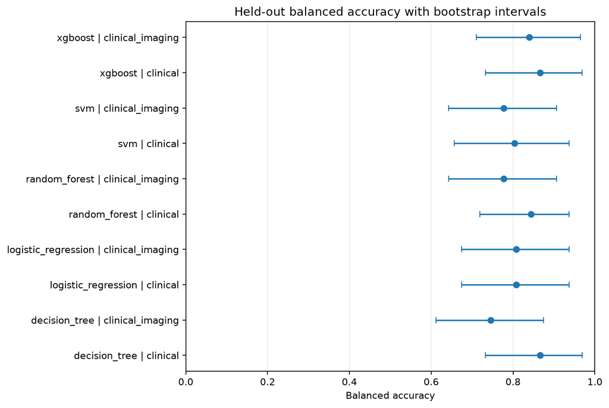

Balanced accuracy with percentile bootstrap intervals.

|  | Algorithm | Imaging - clinical | 95% lower | 95% upper |
| --- | --- | --- | --- | --- |
| 0 | decision_tree | -0.121 | -0.290 | 0.045 |
| 1 | logistic_regression | 0.000 | 0.000 | 0.000 |
| 2 | random_forest | -0.067 | -0.196 | 0.062 |
| 3 | svm | -0.027 | -0.125 | 0.076 |
| 4 | xgboost | -0.027 | -0.125 | 0.076 |

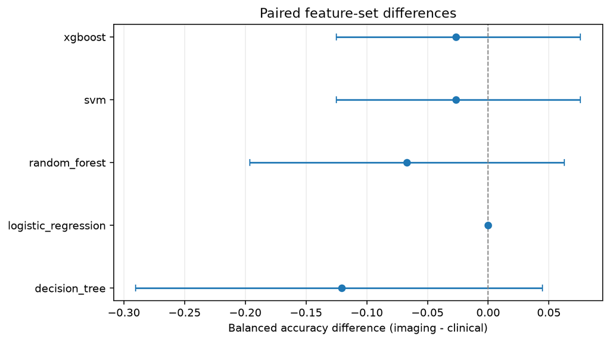

Paired imaging-minus-clinical balanced-accuracy differences.

Every paired interval includes zero. The available evidence therefore does not show a stable held-out advantage from adding eTIV, nWBV, and ASF.

# 8 Model explanations

This section is explicitly post-hoc. Permutation importance reopens the held-out features and outcomes after the canonical prediction release. It is interpretation of fixed models on this sample, not another formal model evaluation, and it must not influence subsequent model development.

Permutation importance provides one original-feature comparison across all 10 fixed models. It measures the held-out balanced-accuracy change after permuting one feature; it does not refit a model or select features.

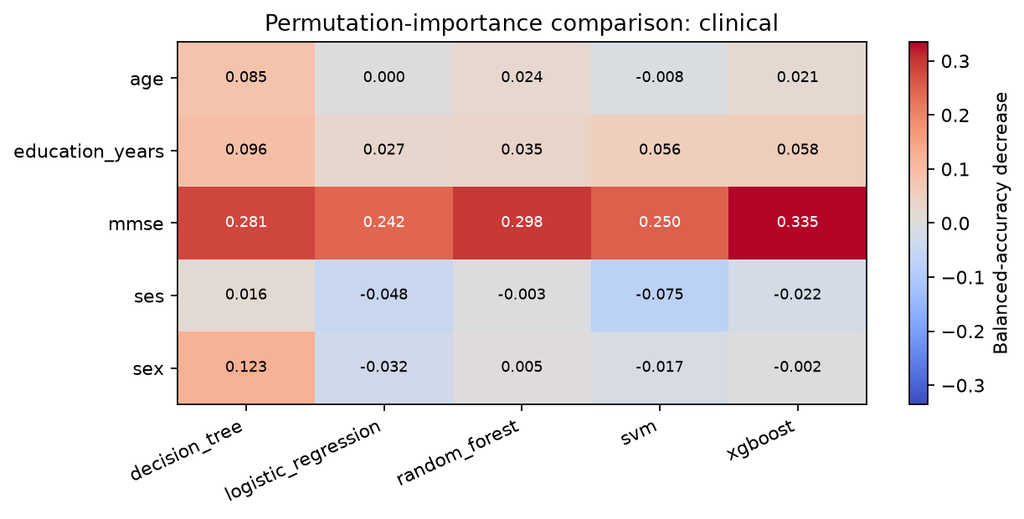

Clinical permutation-importance matrix.

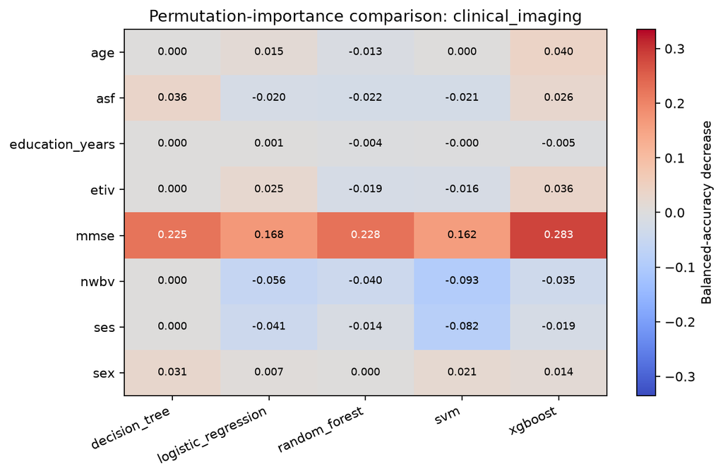

Clinical-imaging permutation-importance matrix.

|  | Algorithm | Feature setting | Top feature | Mean decrease | SD |
| --- | --- | --- | --- | --- | --- |
| 0 | decision_tree | clinical | mmse | 0.281 | 0.078 |
| 1 | decision_tree | clinical_imaging | mmse | 0.225 | 0.075 |
| 2 | logistic_regression | clinical | mmse | 0.242 | 0.087 |
| 3 | logistic_regression | clinical_imaging | mmse | 0.168 | 0.081 |
| 4 | random_forest | clinical | mmse | 0.298 | 0.083 |
| 5 | random_forest | clinical_imaging | mmse | 0.228 | 0.087 |
| 6 | svm | clinical | mmse | 0.250 | 0.078 |
| 7 | svm | clinical_imaging | mmse | 0.162 | 0.080 |
| 8 | xgboost | clinical | mmse | 0.335 | 0.083 |
| 9 | xgboost | clinical_imaging | mmse | 0.283 | 0.090 |

MMSE is the largest permutation feature in every experiment. Negative values elsewhere mean permutation sometimes improved this small held-out score; they are not evidence that a feature is protective or should be removed.

## 8.1 Logistic coefficients

Numeric coefficients are expressed per one training-standard-deviation change. The sex term is one male-versus-female contrast. Exponentiated coefficients are adjusted model odds ratios, not causal effects.

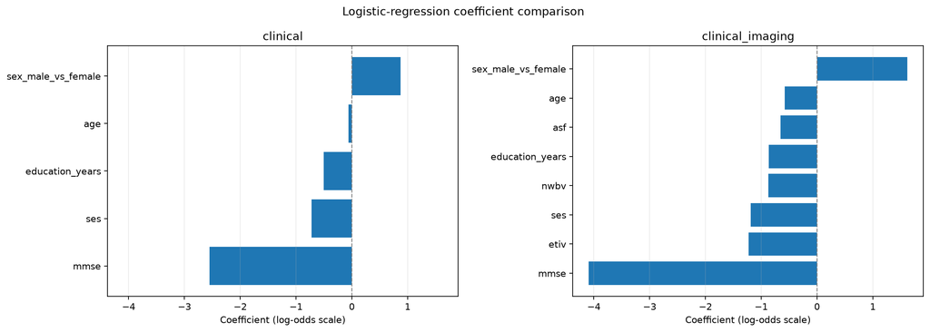

Logistic coefficient comparison.

|  | Feature setting | Term | Coefficient | Odds ratio | Unit |
| --- | --- | --- | --- | --- | --- |
| 0 | clinical | age | -0.063 | 0.939 | one_training_standard_deviation |
| 1 | clinical | education_years | -0.506 | 0.603 | one_training_standard_deviation |
| 2 | clinical | ses | -0.720 | 0.487 | one_training_standard_deviation |
| 3 | clinical | mmse | -2.551 | 0.078 | one_training_standard_deviation |
| 4 | clinical | sex_male_vs_female | 0.872 | 2.393 | male_vs_female |
| 5 | clinical_imaging | age | -0.582 | 0.559 | one_training_standard_deviation |
| 6 | clinical_imaging | education_years | -0.869 | 0.420 | one_training_standard_deviation |
| 7 | clinical_imaging | ses | -1.188 | 0.305 | one_training_standard_deviation |
| 8 | clinical_imaging | mmse | -4.093 | 0.017 | one_training_standard_deviation |
| 9 | clinical_imaging | etiv | -1.230 | 0.292 | one_training_standard_deviation |
| 10 | clinical_imaging | nwbv | -0.871 | 0.419 | one_training_standard_deviation |
| 11 | clinical_imaging | asf | -0.655 | 0.519 | one_training_standard_deviation |
| 12 | clinical_imaging | sex_male_vs_female | 1.620 | 5.056 | male_vs_female |

## 8.2 Tree SHAP

Tree SHAP [assigns additive feature contributions to individual model predictions](https://papers.neurips.cc/paper_files/paper/2017/hash/8a20a8621978632d76c43dfd28b67767-Abstract.html). The decision-tree and random-forest explanations use class-1 probability units; XGBoost uses raw-margin units. Magnitudes are not compared across these output scales.

|  | Algorithm | Feature setting | Feature | Output scale | Mean absolute SHAP |
| --- | --- | --- | --- | --- | --- |
| 0 | decision_tree | clinical | mmse | class_1_probability | 0.279 |
| 1 | decision_tree | clinical | sex | class_1_probability | 0.096 |
| 2 | decision_tree | clinical | education_years | class_1_probability | 0.053 |
| 3 | decision_tree | clinical_imaging | mmse | class_1_probability | 0.256 |
| 4 | decision_tree | clinical_imaging | sex | class_1_probability | 0.091 |
| 5 | decision_tree | clinical_imaging | nwbv | class_1_probability | 0.066 |
| 6 | random_forest | clinical | mmse | class_1_probability | 0.134 |
| 7 | random_forest | clinical | sex | class_1_probability | 0.045 |
| 8 | random_forest | clinical | education_years | class_1_probability | 0.029 |
| 9 | random_forest | clinical_imaging | mmse | class_1_probability | 0.163 |
| 10 | random_forest | clinical_imaging | nwbv | class_1_probability | 0.056 |
| 11 | random_forest | clinical_imaging | sex | class_1_probability | 0.026 |
| 12 | xgboost | clinical | mmse | raw_margin | 1.137 |
| 13 | xgboost | clinical | sex | raw_margin | 0.372 |
| 14 | xgboost | clinical | education_years | raw_margin | 0.146 |
| 15 | xgboost | clinical_imaging | mmse | raw_margin | 0.898 |
| 16 | xgboost | clinical_imaging | nwbv | raw_margin | 0.297 |
| 17 | xgboost | clinical_imaging | sex | raw_margin | 0.202 |

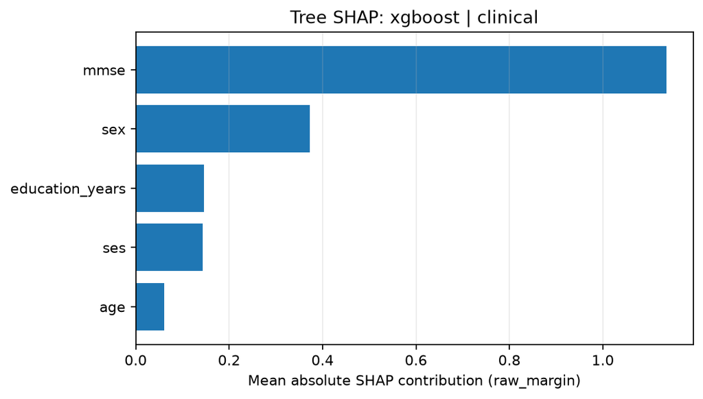

XGBoost SHAP importance for clinical predictors.

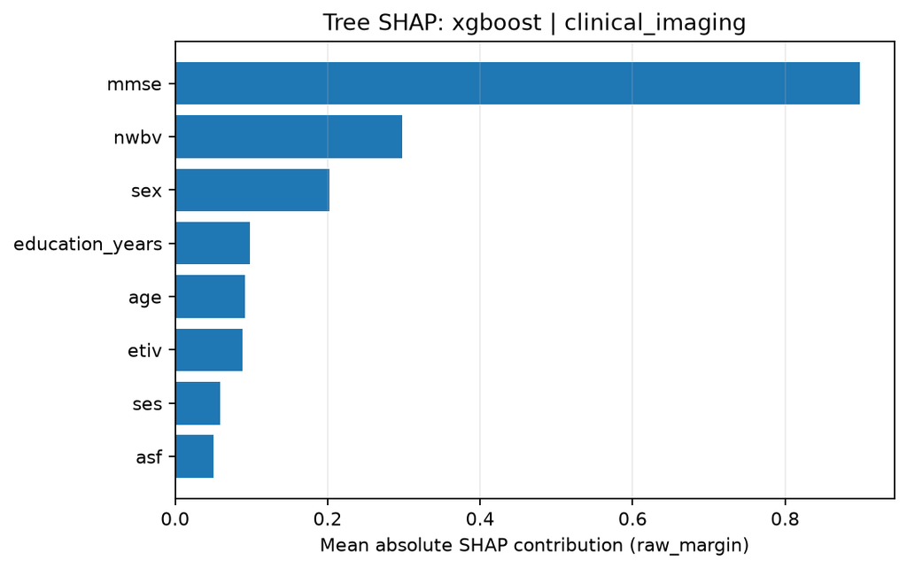

XGBoost SHAP importance with imaging predictors.

nWBV is prominent in the imaging tree-SHAP summaries but weak or negative under permutation importance. This method-dependent pattern is compatible with correlated predictors sharing information; it is not stable evidence that nWBV has an independent or causal role.

# 9 Limitations

- The held-out partition contains only 30 subjects, producing broad and sample-specific uncertainty.
- The highest-visit design is cross-sectional at the subject level and does not model trajectories or future conversion.
- MMSE is contemporaneous with the target and may dominate other predictors; the project does not claim screening performance without cognitive testing.
- Converted subjects are assigned to the dementia class by the confirmed project definition.
- Permutation importance can understate correlated variables.
- SHAP explains model behavior, not clinical importance, validity, or causality.
- No subgroup analysis, calibration study, externally validated threshold, or independent cohort evaluation was performed.
- Synthetic quality is based on only 120 real training subjects per generator; synthetic data may reproduce biases or reveal patterns from the source data and are not a privacy mechanism.

# 10 Reproducibility

The canonical environment requires Python 3.12+, XGBoost 3.4.0, SHAP 0.52.0, and SDV 1.37.3. The implementation uses scikit-learn pipelines ([Pedregosa et al., 2011](https://www.jmlr.org/papers/v12/pedregosa11a.html)), XGBoost ([Chen and Guestrin, 2016](https://arxiv.org/abs/1603.02754)), and SHAP ([Lundberg and Lee, 2017](https://papers.neurips.cc/paper_files/paper/2017/hash/8a20a8621978632d76c43dfd28b67767-Abstract.html)).

Rendering this document reads the saved JSON, CSV, and PNG artifacts above. It does not import project modeling modules, load fitted models, or rerun cleaning, tuning, training, held-out evaluation, bootstrap validation, or explanation.

# 11 Conclusion

This project demonstrates a reproducible, leakage-aware comparison of dementia classification with and without structured MRI-derived variables and with and without synthetic training augmentation. Augmentation improved or tied all ten paired held-out point estimates, but nine paired augmentation intervals included zero. The one interval excluding zero remains unadjusted and conditional on a small, reused test sample. The real-only bootstrap analysis also did not establish an MRI benefit. These findings remain exploratory—not clinical evidence, a privacy claim, or a diagnostic system.